# Titanic Data Anlysis

RMS Titanic was a British passenger liner that sank in the North Atlantic Ocean in the early morning of 15 April 1912, after colliding with an iceberg during her maiden voyage from Southampton to New York City. Of the 2,224 passengers and crew aboard, more than 1,500 died in the sinking, making it one of the deadliest commercial peacetime maritime disasters in modern history.

We have a sample of demographic data for all passengers which aboard Titanic. We will do some analysis to find some insights from data.

## A. High Level Overview Of Data

We will import the data which is presenet in csv file. We will try to explore some high level informaation from data

```python
#import importanat libraries
import matplotlib.pyplot as plt
import numpy as np
import pandas as pd
import seaborn as sns
%pylab inline
```

```python
#import the data in data from
path_to_csv_file='./Titanic.csv'
titanic_df=pd.read_csv(path_to_csv_file)
```

```python
#Let us print out some to get some overview of data
titanic_df.head(5)
```

|  | PassengerId | Survived | Pclass | Name | Sex | Age | SibSp | Parch | Ticket | Fare | Cabin | Embarked |
| --- | --- | --- | --- | --- | --- | --- | --- | --- | --- | --- | --- | --- |
| 0 | 1 | 0 | 3 | Braund, Mr. Owen Harris | male | 22.0 | 1 | 0 | A/5 21171 | 7.2500 | NaN | S |
| 1 | 2 | 1 | 1 | Cumings, Mrs. John Bradley (Florence Briggs Th... | female | 38.0 | 1 | 0 | PC 17599 | 71.2833 | C85 | C |
| 2 | 3 | 1 | 3 | Heikkinen, Miss. Laina | female | 26.0 | 0 | 0 | STON/O2. 3101282 | 7.9250 | NaN | S |
| 3 | 4 | 1 | 1 | Futrelle, Mrs. Jacques Heath (Lily May Peel) | female | 35.0 | 1 | 0 | 113803 | 53.1000 | C123 | S |
| 4 | 5 | 0 | 3 | Allen, Mr. William Henry | male | 35.0 | 0 | 0 | 373450 | 8.0500 | NaN | S |

Where VARIABLE DESCRIPTIONS: survival Survival (0 = No; 1 = Yes) pclass Passenger Class (1 = 1st; 2 = 2nd; 3 = 3rd) name Name sex Sex age Age sibsp Number of Siblings/Spouses Aboard parch Number of Parents/Children Aboard ticket Ticket Number fare Passenger Fare cabin Cabin embarked Port of Embarkation (C = Cherbourg; Q = Queenstown; S = Southampton)

Let us als use pandas describe function to get information.

```python
#information about data
titanic_df.describe()
```

|  | PassengerId | Survived | Pclass | Age | SibSp | Parch | Fare |
| --- | --- | --- | --- | --- | --- | --- | --- |
| count | 891.000000 | 891.000000 | 891.000000 | 714.000000 | 891.000000 | 891.000000 | 891.000000 |
| mean | 446.000000 | 0.383838 | 2.308642 | 29.699118 | 0.523008 | 0.381594 | 32.204208 |
| std | 257.353842 | 0.486592 | 0.836071 | 14.526497 | 1.102743 | 0.806057 | 49.693429 |
| min | 1.000000 | 0.000000 | 1.000000 | 0.420000 | 0.000000 | 0.000000 | 0.000000 |
| 25% | 223.500000 | 0.000000 | 2.000000 | NaN | 0.000000 | 0.000000 | 7.910400 |
| 50% | 446.000000 | 0.000000 | 3.000000 | NaN | 0.000000 | 0.000000 | 14.454200 |
| 75% | 668.500000 | 1.000000 | 3.000000 | NaN | 1.000000 | 0.000000 | 31.000000 |
| max | 891.000000 | 1.000000 | 3.000000 | 80.000000 | 8.000000 | 6.000000 | 512.329200 |

## B. Questions to Answer

After getting overview of data, we want to know affect of following on sruvival 1. Are more Children saved? 2. survival rate between different classes? 4. survival rate based on Gender?

## C. Preparing data

From looking at data, we know that there are some columns which will not be used in our analysis, as they don't contribute much information.

1. Name: We know that name of a person has no affect unless we are doing some more research into persons population records.
2. Fare: Similarly the Price of ticket is also unrelated, because we are not going to analyse the fares. Also we have cabin class information, which gives us idea of which level of ship each person was staying.
3. Ticket: Ticket number is also irrelevant computer generated infromation.

```python
#Let us drop undesired Columns
titanic_df=titanic_df.drop(['Name','Fare','Ticket'],axis=1,inplace=False)
titanic_df.head(5)
```

|  | PassengerId | Survived | Pclass | Sex | Age | SibSp | Parch | Cabin | Embarked |
| --- | --- | --- | --- | --- | --- | --- | --- | --- | --- |
| 0 | 1 | 0 | 3 | male | 22.0 | 1 | 0 | NaN | S |
| 1 | 2 | 1 | 1 | female | 38.0 | 1 | 0 | C85 | C |
| 2 | 3 | 1 | 3 | female | 26.0 | 0 | 0 | NaN | S |
| 3 | 4 | 1 | 1 | female | 35.0 | 1 | 0 | C123 | S |
| 4 | 5 | 0 | 3 | male | 35.0 | 0 | 0 | NaN | S |

As alot of our analyses will be based on age of people. We feel that records which don't have Age doesn't seem to be good for our analysis.

From analysis earlier, we saw that the total records with Age present were 714, but the total for PassengerId were 891. So we will go ahead and drop the extra records without age.

```python
#Let us drop the null values as we are not interested in people without age
titanic_df=titanic_df.dropna(subset = ['Age'])
titanic_df.describe()
```

|  | PassengerId | Survived | Pclass | Age | SibSp | Parch |
| --- | --- | --- | --- | --- | --- | --- |
| count | 714.000000 | 714.000000 | 714.000000 | 714.000000 | 714.000000 | 714.000000 |
| mean | 448.582633 | 0.406162 | 2.236695 | 29.699118 | 0.512605 | 0.431373 |
| std | 259.119524 | 0.491460 | 0.838250 | 14.526497 | 0.929783 | 0.853289 |
| min | 1.000000 | 0.000000 | 1.000000 | 0.420000 | 0.000000 | 0.000000 |
| 25% | 222.250000 | 0.000000 | 1.000000 | 20.125000 | 0.000000 | 0.000000 |
| 50% | 445.000000 | 0.000000 | 2.000000 | 28.000000 | 0.000000 | 0.000000 |
| 75% | 677.750000 | 1.000000 | 3.000000 | 38.000000 | 1.000000 | 1.000000 |
| max | 891.000000 | 1.000000 | 3.000000 | 80.000000 | 5.000000 | 6.000000 |

We are also assuming that if a passenger is younger than 18 years of age, then he is a child. We will add another column to our DataFrame based on this condition.

```python
#new boolean column 'isChild' for separating children and adults.
titanic_df['isChild']=titanic_df[['Age']] <= 17
titanic_df.head(5)
```

|  | PassengerId | Survived | Pclass | Sex | Age | SibSp | Parch | Cabin | Embarked | isChild |
| --- | --- | --- | --- | --- | --- | --- | --- | --- | --- | --- |
| 0 | 1 | 0 | 3 | male | 22.0 | 1 | 0 | NaN | S | False |
| 1 | 2 | 1 | 1 | female | 38.0 | 1 | 0 | C85 | C | False |
| 2 | 3 | 1 | 3 | female | 26.0 | 0 | 0 | NaN | S | False |
| 3 | 4 | 1 | 1 | female | 35.0 | 1 | 0 | C123 | S | False |
| 4 | 5 | 0 | 3 | male | 35.0 | 0 | 0 | NaN | S | False |

```python
#Convert Survival to boolean
titanic_df.loc[:,"Survived"] = titanic_df["Survived"].astype(bool)
```

We will also another column to separate single people from people with families e.g People with families or Spouses.

```python
#function for column 'isChild' for separating children and adults.
def is_with_family(row):
    if row['Parch'] > 0:
        return True
    elif row['SibSp'] > 0:
        return True
    else:
        return False

titanic_df['isWithFamily']=titanic_df.apply(is_with_family, axis=1)
titanic_df.head(5)
```

|  | PassengerId | Survived | Pclass | Sex | Age | SibSp | Parch | Cabin | Embarked | isChild | isWithFamily |
| --- | --- | --- | --- | --- | --- | --- | --- | --- | --- | --- | --- |
| 0 | 1 | False | 3 | male | 22.0 | 1 | 0 | NaN | S | False | True |
| 1 | 2 | True | 1 | female | 38.0 | 1 | 0 | C85 | C | False | True |
| 2 | 3 | True | 3 | female | 26.0 | 0 | 0 | NaN | S | False | False |
| 3 | 4 | True | 1 | female | 35.0 | 1 | 0 | C123 | S | False | True |
| 4 | 5 | False | 3 | male | 35.0 | 0 | 0 | NaN | S | False | False |

## D.1 Are more children saved?

First of all let us see what is the age distrubution of survived people

```python
#Function to group by list of columns provided and then return Series with counts
def grouper(df, list_columns,):
    """Function which will group the data from based on list of columns provided
    and will return the counts"""
    return df.groupby(list_columns)
```

```python
total_survived=titanic_df[titanic_df['Survived']]
total_survived.describe()
```

|  | PassengerId | Pclass | Age | SibSp | Parch |
| --- | --- | --- | --- | --- | --- |
| count | 290.000000 | 290.000000 | 290.000000 | 290.000000 | 290.000000 |
| mean | 457.768966 | 1.872414 | 28.343690 | 0.493103 | 0.527586 |
| std | 250.845515 | 0.836617 | 14.950952 | 0.731132 | 0.807147 |
| min | 2.000000 | 1.000000 | 0.420000 | 0.000000 | 0.000000 |
| 25% | 260.500000 | 1.000000 | 19.000000 | 0.000000 | 0.000000 |
| 50% | 452.000000 | 2.000000 | 28.000000 | 0.000000 | 0.000000 |
| 75% | 669.500000 | 3.000000 | 36.000000 | 1.000000 | 1.000000 |
| max | 890.000000 | 3.000000 | 80.000000 | 4.000000 | 5.000000 |

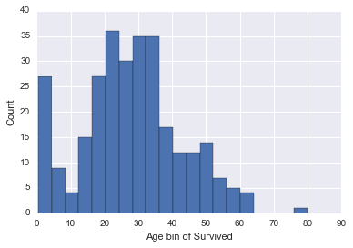

```python
total_survived['Age'].hist(bins=20)
plt.xlabel('Age bin of Survived')
plt.ylabel('Count')
```

Now let us use this new function to get some more information.

```python
survival_by_age=grouper(titanic_df,['isChild'])
survival_by_age.describe()
```

| isChild |  | Age | Parch | PassengerId | Pclass | SibSp |
| --- | --- | --- | --- | --- | --- | --- |
| False | count | 601.000000 | 601.000000 | 601.000000 | 601.000000 | 601.000000 |
|  | mean | 33.583195 | 0.314476 | 452.224626 | 2.171381 | 0.334443 |
|  | std | 12.185705 | 0.811957 | 254.728694 | 0.849851 | 0.577028 |
|  | min | 18.000000 | 0.000000 | 1.000000 | 1.000000 | 0.000000 |
|  | 25% | 24.000000 | 0.000000 | 233.000000 | 1.000000 | 0.000000 |
|  | 50% | 31.000000 | 0.000000 | 451.000000 | 2.000000 | 0.000000 |
|  | 75% | 40.000000 | 0.000000 | 672.000000 | 3.000000 | 1.000000 |
|  | max | 80.000000 | 6.000000 | 891.000000 | 3.000000 | 3.000000 |
| True | count | 113.000000 | 113.000000 | 113.000000 | 113.000000 | 113.000000 |
|  | mean | 9.041327 | 1.053097 | 429.212389 | 2.584071 | 1.460177 |
|  | std | 6.030408 | 0.800008 | 281.743819 | 0.677781 | 1.625881 |
|  | min | 0.420000 | 0.000000 | 8.000000 | 1.000000 | 0.000000 |
|  | 25% | 3.000000 | 0.000000 | 172.000000 | 2.000000 | 0.000000 |
|  | 50% | 9.000000 | 1.000000 | 420.000000 | 3.000000 | 1.000000 |
|  | 75% | 16.000000 | 2.000000 | 721.000000 | 3.000000 | 3.000000 |
|  | max | 17.000000 | 3.000000 | 876.000000 | 3.000000 | 5.000000 |

```
Survival rate of Children vs Adults
isChild
False    0.381032
True     0.539823
Name: Survived, dtype: float64
```

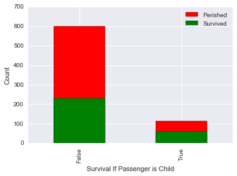

```python
total = survival_by_age["Survived"].count()
survived = survival_by_age["Survived"].sum().astype(int)
print 'Survival rate of Children vs Adults'
print survival_by_age["Survived"].mean()
print ''
total.plot(kind="bar", color="r", label="Perished")
survived.plot(kind="bar", color="g", label="Survived")
plt.legend(loc=1)
plt.xlabel('Survival If Passenger is Child')
plt.ylabel('Count')
```

From "Survival rate of Children vs Adults" statistics above and plot, we can see that almost 54% of kids were saved, while only 38% adults were saved only.

## D.2 survival rate between different classes?

```python
survival_by_class = grouper(titanic_df,['Pclass'])
survival_by_class.describe()
```

| Pclass |  | Age | Parch | PassengerId | SibSp |
| --- | --- | --- | --- | --- | --- |
| 1 | count | 186.000000 | 186.000000 | 186.000000 | 186.000000 |
|  | mean | 38.233441 | 0.408602 | 463.962366 | 0.451613 |
|  | std | 14.802856 | 0.731331 | 246.460706 | 0.632731 |
|  | min | 0.920000 | 0.000000 | 2.000000 | 0.000000 |
|  | 25% | 27.000000 | 0.000000 | 271.000000 | 0.000000 |
|  | 50% | 37.000000 | 0.000000 | 486.000000 | 0.000000 |
|  | 75% | 49.000000 | 1.000000 | 669.750000 | 1.000000 |
|  | max | 80.000000 | 4.000000 | 890.000000 | 3.000000 |
| 2 | count | 173.000000 | 173.000000 | 173.000000 | 173.000000 |
|  | mean | 29.877630 | 0.404624 | 447.156069 | 0.427746 |
|  | std | 14.001077 | 0.705775 | 253.387868 | 0.611645 |
|  | min | 0.670000 | 0.000000 | 10.000000 | 0.000000 |
|  | 25% | 23.000000 | 0.000000 | 233.000000 | 0.000000 |
|  | 50% | 29.000000 | 0.000000 | 433.000000 | 0.000000 |
|  | 75% | 36.000000 | 1.000000 | 671.000000 | 1.000000 |
|  | max | 70.000000 | 3.000000 | 887.000000 | 3.000000 |
| 3 | count | 355.000000 | 355.000000 | 355.000000 | 355.000000 |
|  | mean | 25.140620 | 0.456338 | 441.219718 | 0.585915 |
|  | std | 12.495398 | 0.971447 | 268.541525 | 1.157303 |
|  | min | 0.420000 | 0.000000 | 1.000000 | 0.000000 |
|  | 25% | 18.000000 | 0.000000 | 195.500000 | 0.000000 |
|  | 50% | 24.000000 | 0.000000 | 425.000000 | 0.000000 |
|  | 75% | 32.000000 | 1.000000 | 683.500000 | 1.000000 |
|  | max | 74.000000 | 6.000000 | 891.000000 | 5.000000 |

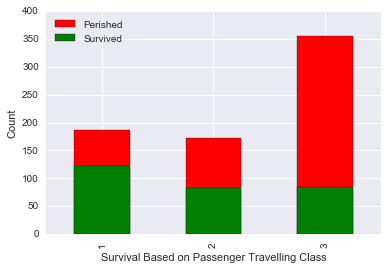

```python
total = survival_by_class["Survived"].count()
survived = survival_by_class["Survived"].sum().astype(int)
total.plot(kind="bar", color="r", label="Perished")
survived.plot(kind="bar", color="g", label="Survived")
plt.legend(loc=2)
plt.xlabel('Survival Based on Passenger Travelling Class')
plt.ylabel('Count')
```

```python
print 'Survival Rate based on Class'
print survival_by_class["Survived"].mean()
```

```
Survival Rate based on Class
Pclass
1    0.655914
2    0.479769
3    0.239437
Name: Survived, dtype: float64
```

From plot above we can see the people in first class had higher chances of survival about 65.5%. But people in 3rd class had very few chances of survival about 24%. People in 2nd class have about 50/50 chances. It also might be because 1st class passengers get higher level decks with better views, while the 3rd class passengers are at the bottom without any windows. When water came inside, people in the lowest decks travelling in 3rd class were drowned and died first.

## D.3 survival rate based on Gender?

Let us see if Women were saved more along with children.

```python
survival_by_gender = grouper(titanic_df,['Sex'])
survival_by_gender.describe()
```

| Sex |  | Age | Parch | PassengerId | Pclass | SibSp |
| --- | --- | --- | --- | --- | --- | --- |
| female | count | 261.000000 | 261.000000 | 261.000000 | 261.000000 | 261.000000 |
|  | mean | 27.915709 | 0.708812 | 440.199234 | 2.065134 | 0.639847 |
|  | std | 14.110146 | 1.066752 | 260.607601 | 0.845560 | 0.928493 |
|  | min | 0.750000 | 0.000000 | 2.000000 | 1.000000 | 0.000000 |
|  | 25% | 18.000000 | 0.000000 | 234.000000 | 1.000000 | 0.000000 |
|  | 50% | 27.000000 | 0.000000 | 428.000000 | 2.000000 | 0.000000 |
|  | 75% | 37.000000 | 1.000000 | 652.000000 | 3.000000 | 1.000000 |
|  | max | 63.000000 | 6.000000 | 888.000000 | 3.000000 | 5.000000 |
| male | count | 453.000000 | 453.000000 | 453.000000 | 453.000000 | 453.000000 |
|  | mean | 30.726645 | 0.271523 | 453.412804 | 2.335541 | 0.439294 |
|  | std | 14.678201 | 0.651076 | 258.423367 | 0.818748 | 0.923609 |
|  | min | 0.420000 | 0.000000 | 1.000000 | 1.000000 | 0.000000 |
|  | 25% | 21.000000 | 0.000000 | 221.000000 | 2.000000 | 0.000000 |
|  | 50% | 29.000000 | 0.000000 | 456.000000 | 3.000000 | 0.000000 |
|  | 75% | 39.000000 | 0.000000 | 684.000000 | 3.000000 | 1.000000 |
|  | max | 80.000000 | 5.000000 | 891.000000 | 3.000000 | 5.000000 |

```
array([<matplotlib.axes._subplots.AxesSubplot object at 0x122691690>], dtype=object)
```

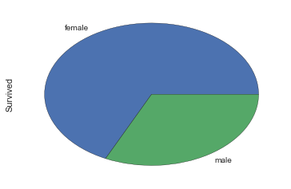

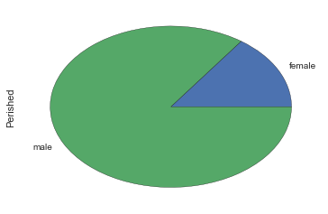

```python
total = survival_by_gender["Survived"].count()
survived = survival_by_gender["Survived"].sum().astype(int)
perished=(total-survived).astype(int)

#Plot for Survived
plt.figure(0)
survived.plot(kind='pie', subplots=True, figsize=(5, 5))

#plt of Perished
plt.figure(1)
perished.plot(kind='pie', subplots=True, figsize=(5, 5),label='Perished')
```

From pie chart above, we can easily see that There is majority of Men who perished, while there is Majority of Women who were saved.

## E. Conclusion

Limitations

1. The size of the sample is small which can skew the data
2. There are also unknows, if passengers were crew members or not.
3. There are also some missing ages which can change results too.

Conclusion

1. From data we can see that more Women and Children were saved.
2. We can also see that rich passengers travelling in 1st class were saved more.

## F. Sources

https://en.wikipedia.org/wiki/RMS_Titanic